# UNRISK EBMulation

JS, thanks to DW

Reproducing UNRISK training emulation/calibration example.

```r
setwd('..')
tmp <- getwd()
source(paste0(tmp, '/plot.R'))
source(paste0(tmp, '/basis.R'))
source(paste0(tmp, '/emulate.R'))
source(paste0(tmp, '/calibrate.R'))
source(paste0(tmp, '/data/EBM.R'))
# Currently need to load ggplot2 explicitly
library(ggplot2)
# FitEmulator options: method = 'gp' or 'dgp' don't work in Rmd, but do in R
```

Generate initial design on $[0,1]^2$:

```r
set.seed(302)
n0 <- 12
X0 <- lhs::maximinLHS(n0, 2)
head(X0)
```

```
##            [,1]      [,2]
## [1,] 0.73353900 0.6828755
## [2,] 0.08401851 0.3388071
## [3,] 0.38987897 0.9177802
## [4,] 0.87956362 0.3181722
## [5,] 0.32863856 0.6295111
## [6,] 0.93976543 0.5590058
```

The EBM has 2 inputs: `lambda`, `C`. The simulation model code `ebm_output` converts the given inputs from $[0,1]$ to the required ranges.

Running the EBM at this set of inputs to generate a PPE:

```r
ppe <- ebm_output(X0)
dim(ppe)
```

```
## [1] 251  12
```

The output is 251 (number of outputs, years) x 12 (number of simulations).

To use the plotting functionality within the package, we first process the PPE into a `DataBasis` object:

```r
DataBasis <- MakeDataBasis(ppe)
```

This contains various outputs, most of which we’ll use later:

```r
summary(DataBasis)
```

```
##              Length Class  Mode
## tBasis       2761   -none- numeric
## CentredField 3012   -none- numeric
## EnsembleMean  251   -none- numeric
## Coeffs        132   -none- numeric
```

It will be helpful for plotting throughout to add to the `$grid` slot some information about what set of locations (longitude, latitude, time, etc.) the 251 outputs relate to. Here, the years from 1850-2100:

```r
DataBasis$grid <- data.frame(Year = years_all)
```

Plotting the PPE, we see that the x axis is automatically labelled by year 1850-2100:

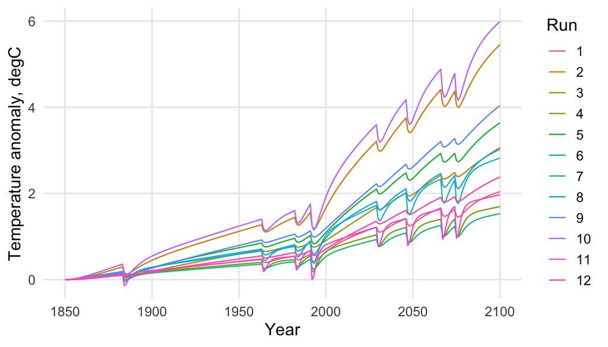

```r
ppe_plot <- PlotData(DataBasis) +
  theme_minimal(base_size = 14) +
  theme(panel.grid.minor = element_blank(),
        strip.text = element_text(face = "bold")) +
  labs(col = 'Run', y = 'Temperature anomaly, degC')

ppe_plot
```

We could instead split by simulation:

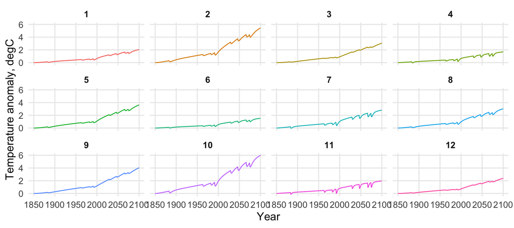

```r
ppe_plot + facet_wrap(vars(Run)) + theme(legend.position = 'none')
```

## Emulation

First split into a training and validation set, here deliberately withholding one of the more extreme runs:

```r
train_inds <- c(1:9,11)
val_inds <- c(10,12)
```

If we want to emulate the full output (1850-2100), there’s different ways we could approach this, each with pros and cons.

### Emulate all

First we’ll emulate all outputs independently. Creating a data frame where row $i$ contains the values of `lambda` and `C` for the $i^{th}$ simulation, followed by the temperature anomaly for each year of that simulation:

```r
design <- data.frame(lambda = X0[,1], C = X0[,2])

# Combine inputs with outputs
tData_all <- data.frame(design,
                        t(ppe))

dim(tData_all)
```

```
## [1]  12 253
```

```r
# Assign more informative column names to the outputs
colnames(tData_all)[-c(1:2)] <- paste0('T', years_all)
```

Years 1850 and 1851 are exactly zero for all PPE members:

```r
ppe[1:2,]
```

```
##      [,1] [,2] [,3] [,4] [,5] [,6] [,7] [,8] [,9] [,10] [,11] [,12]
## [1,]    0    0    0    0    0    0    0    0    0     0     0     0
## [2,]    0    0    0    0    0    0    0    0    0     0     0     0
```

Hence we can’t fit an emulator to these years (and there’s no need to). For neatness, we’ll now remove these 2 years and recreate the above data frames:

```r
DataBasis <- MakeDataBasis(ppe[-c(1:2),])
DataBasis$grid <- data.frame(Year = years_all[-c(1:2)])
tData_all <- data.frame(design, t(ppe[-c(1:2),]))
colnames(tData_all)[-c(1:2)] <- paste0('T', years_all[-c(1:2)])
```

Using function `FitEmulators` we can loop over all outputs and train an emulator using `lambda`, `C` as inputs. To do so, we can provide the input and output columns as either names or indices relating to the training dataset. Training emulators for the simulator output for all years 1852-2100:

```r
em_all <- FitEmulators(tData_all[train_inds,], input = c('lambda','C'), output = colnames(tData_all)[-c(1:2)])
```

The `em_all` object is a list of 249 emulators, 1 for each year:

```r
length(em_all)
```

```
## [1] 249
```

We can look at leave-one-out plots for any of the emulators. Considering a subset:

```r
em_names <- unlist(lapply(1:length(em_all), function(k) em_all[[k]]$response))
loo_all <- LeaveOneOut(em_all[c(which(em_names %in% c('T1950','T2000','T2050','T2100')))], by_index = TRUE)
```

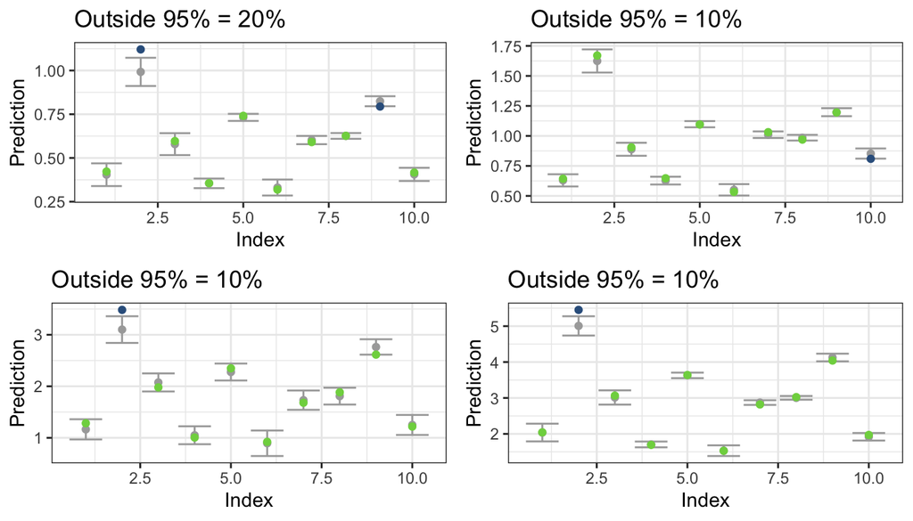

Prediction can be applied across the full set of emulators, for any given inputs. Here, we’ll predict for the 2 points from our validation set so that we can compare to the true simulator output at these inputs:

```r
preds <- Predict(em_all, design[val_inds,])
summary(preds)
```

```
##             Length Class  Mode
## Expectation 498    -none- numeric
## Variance    498    -none- numeric
```

```r
dim(preds$Expectation)
```

```
## [1]   2 249
```

```r
dim(preds$Variance)
```

```
## [1]   2 249
```

The output here is the expectation and variance for each of the 249 emulated years (columns), for each of the 2 validation points (rows).

We could plot the mean and variance, but let’s also sample from the emulators. Function `IndEmSamples` takes a set of means and variances, and draws samples from the relevant Normal distributions - given the assumption that the different emulators are independent:

```r
set.seed(482)
samples <- IndEmSamples(preds, ns = 1000)
```

Alternatively, we could have skipped the `Predict` step, and just provided the function with the emulator and design, with the prediction handled within the function:

```r
set.seed(482)
samples2 <- IndEmSamples(emulator = em_all, design = design[val_inds,], ns = 1000)
summary(c(samples-samples2))
```

```
##    Min. 1st Qu.  Median    Mean 3rd Qu.    Max.
##       0       0       0       0       0       0
```

with the 2 sets of samples identical (given same seed used).

Plotting the resulting samples:

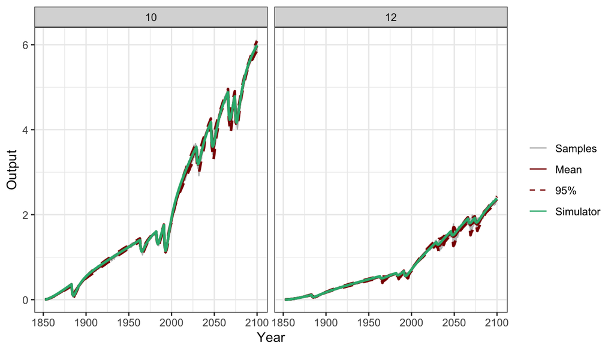

```r
PlotSamples(DataBasis, samples = samples, data_inds = val_inds, sample_inds = 1:10)
```

Similarly, we don’t actually need to have constructed the samples: we could provide `PlotSamples` with the emulator and design:

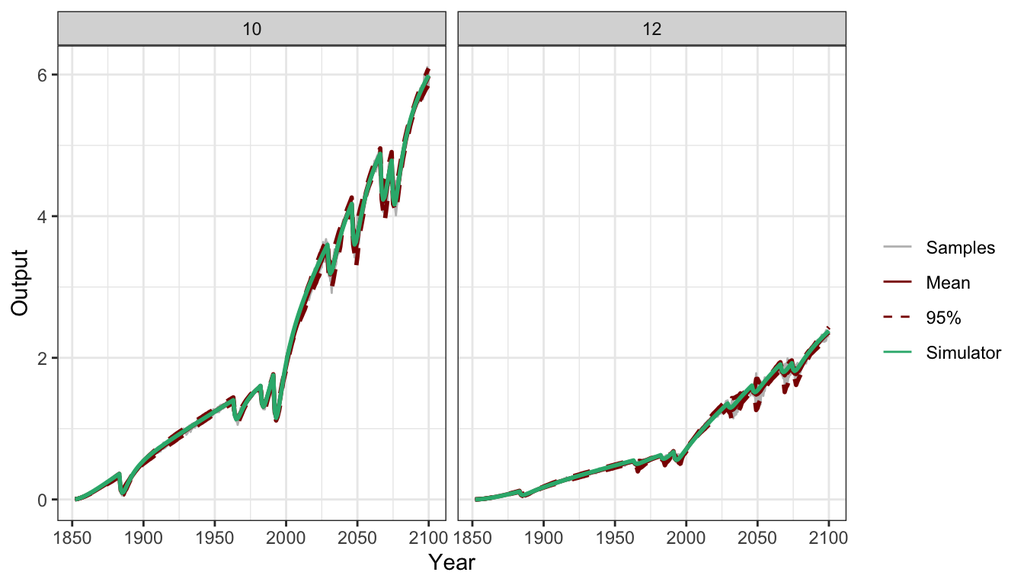

```r
set.seed(482)
PlotSamples(DataBasis, emulator = em_all, design = design[val_inds,], ns = 1000, data_inds = val_inds, sample_inds = 1:10)
```

Broadly, the true simulator output and emulator mean/variance/samples align.

Zooming in to 2050 onwards shows more clearly that there is uncertainty:

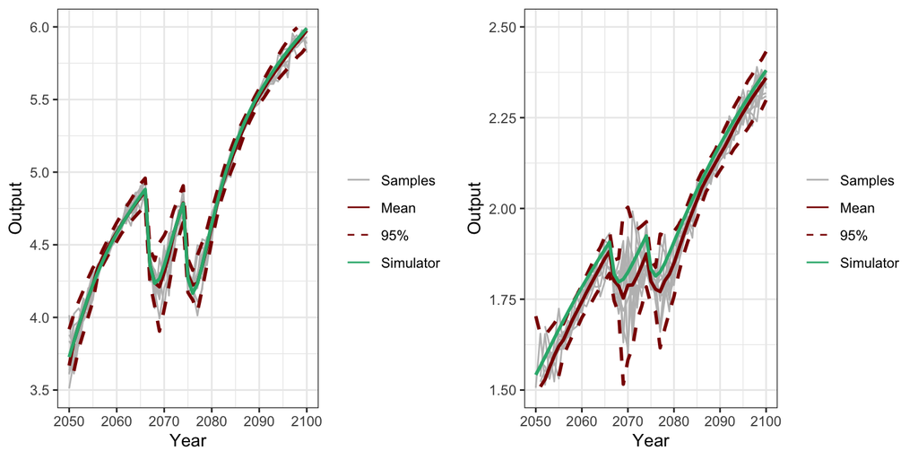

```r
plot1 <- PlotSamples(DataBasis, samples = samples[,,1], data_inds = val_inds[1], sample_inds = 1:10) +
  xlim(2050,2100) + ylim(3.5,6)
plot2 <- PlotSamples(DataBasis, samples = samples[,,2], data_inds = val_inds[2], sample_inds = 1:10) +
  xlim(2050,2100) + ylim(1.5,2.5)
cowplot::plot_grid(plot1, plot2)
```

It looks like the truth is contained within the 95% prediction intervals for almost every year. The uncertainty is also relatively low compared to the variability in the output/across the PPE.

A small number of samples (10) are plotted in grey, and these reflect the independence assumption between the emulators for different years, and can be ‘spiky’.

### Dimension reduction

The above has worked fairly well, but independence might be a poor assumption for data like this. Clearly neighbouring years are correlated with each other, and the samples from our emulator do not reflect this. If the output dimension is much higher than 250, and we have a larger training set, this approach might become computationally inefficient as well.

Instead, let’s consider dimension reduction as a route to emulating the full output. We’ve already created the `DataBasis` object we need, and plotted the full ensemble. To calculate the SVD basis representation, first the ensemble mean is removed, resulting in the below centered ensemble:

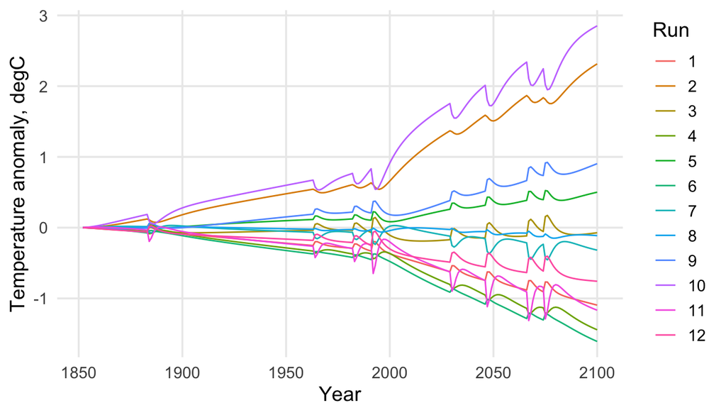

```r
PlotData(DataBasis, AddMean = FALSE) +
  theme_minimal(base_size = 14) +
  theme(panel.grid.minor = element_blank(),
        strip.text = element_text(face = "bold")) +
  labs(col = 'Run', y = 'Temperature anomaly, degC')
```

The ensemble mean is stored in `DataBasis$EnsembleMean`, and the centered simulations in `DataBasis$CentredField`.

The basis is stored in `DataBasis$tBasis`, and can be plotted in a similar way:

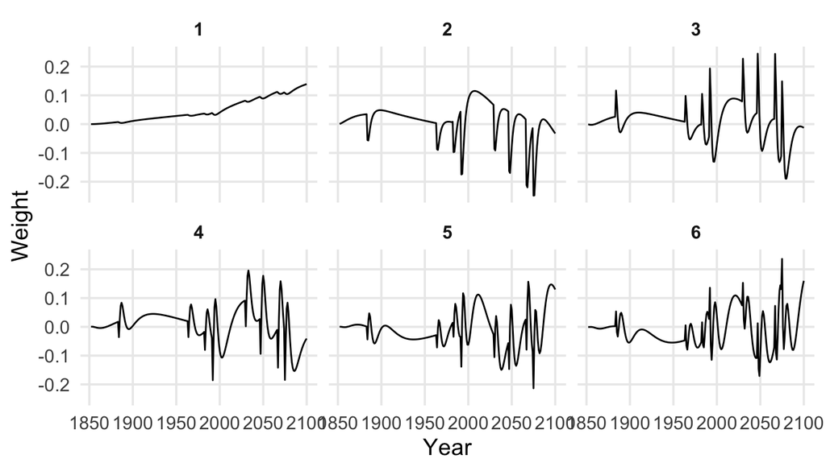

```r
PlotBasis(DataBasis, q = 6) +
  theme_minimal(base_size = 14) +
  theme(panel.grid.minor = element_blank(),
        strip.text = element_text(face = "bold")) +
  labs(y = 'Weight')
```

These are the first 6 basis vectors from the SVD of the centered ensemble. By construction, the first explains as much ensemble variability as possible with a single vector, the second explains as much of the remaining variability subject to orthogonality with the previous, and so on.

Here, the first vector explains over 99% of ensemble variability:

```r
unlist(lapply(1:9, function(k) VarExplained(DataBasis$tBasis[,k], DataBasis$CentredField)))
```

```
## [1] 9.931512e-01 5.935064e-03 8.065088e-04 9.838833e-05 8.545761e-06
## [6] 2.281739e-07 2.217194e-08 7.573871e-10 7.169202e-11
```

This suggests that if we can accurately emulate the coefficients given by projection onto this first basis vector, we should get quite a good approximation of the original full series (as this basis vector/coefficients on it represent the majority of variability in the data). This is also fairly clear from the data itself, where we saw that in general, different ensemble members are just shifted up/down in terms of the temperature anomaly, and so all we really need to capture is the size of this shift dependent on the model inputs - which will be described by the leading coefficient.

Usually we’ll need more vectors to explain 99% or even 90% of the ensemble variability, and it’s really dependent on the data (and often the size of the field). However, even here, there seems to be some explainability given by at least the second vector: it seems to capture a feedback due to the volcanic forcings, which is mostly smoothed out in the first vector. The third may also be capturing some different behaviours around the volcanic forcings, as the spikes seem to align with these.

It’s usually worth trying to emulate more coefficients than you think you need. Here, we’ll try the first 4. If it turns out there’s no signal from the inputs on the coefficients for a given vector, that’s fine, and in the emulator and later calibration we account for uncertainty on these unemulatable patterns via zero-mean noise terms.

The coefficients given by projection of the (centered) simulations onto the basis vectors are already calculated:

```r
dim(DataBasis$Coeffs)
```

```
## [1] 12 11
```

```r
DataBasis$Coeffs[1:10,1:4]
```

```
##                C1          C2          C3          C4
##  [1,]  -7.9001908 -0.21212565  0.34562269  0.07000982
##  [2,]  16.7066087 -0.04897981  0.04316667  0.12236857
##  [3,]  -0.8551818 -1.09428910 -0.23218579 -0.09461129
##  [4,] -10.2639126  0.49999793  0.01257706 -0.06515114
##  [5,]   3.5413527 -0.58829397  0.03576660  0.09725874
##  [6,] -11.5406308  0.07708866  0.29181225 -0.03223103
##  [7,]  -2.0696471  0.98217580 -0.02879826 -0.17812973
##  [8,]  -0.7680679  0.16058301  0.30014583  0.02190153
##  [9,]   6.1677445 -1.15255201 -0.38371154 -0.10196250
## [10,]  20.7173231  0.99464967  0.14889504 -0.05335418
```

Each row is one of the 12 simulations, each column relates to a basis vector.

Combining these coefficients with the inputs, and plotting how the leading coefficients vary in terms of the inputs:

```r
tData_coeffs <- GetEmData(design, DataBasis, q = 4)
head(tData_coeffs)
```

```
##       lambda         C          C1          C2          C3          C4
## 1 0.73353900 0.6828755  -7.9001908 -0.21212565  0.34562269  0.07000982
## 2 0.08401851 0.3388071  16.7066087 -0.04897981  0.04316667  0.12236857
## 3 0.38987897 0.9177802  -0.8551818 -1.09428910 -0.23218579 -0.09461129
## 4 0.87956362 0.3181722 -10.2639126  0.49999793  0.01257706 -0.06515114
## 5 0.32863856 0.6295111   3.5413527 -0.58829397  0.03576660  0.09725874
## 6 0.93976543 0.5590058 -11.5406308  0.07708866  0.29181225 -0.03223103
```

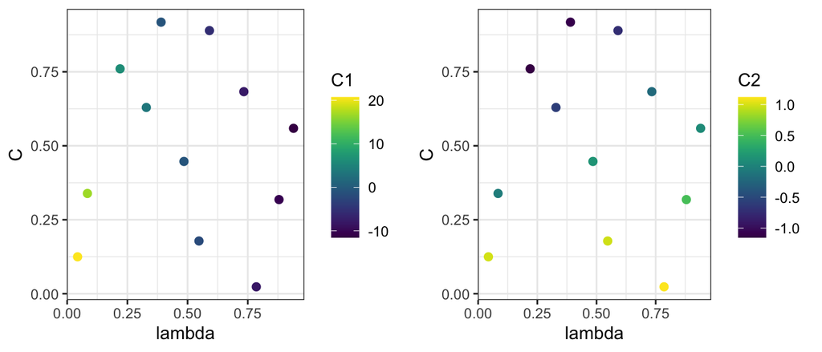

```r
plotC1 <- PlotPair(tData_coeffs, 'lambda', 'C', col = 'C1')
plotC2 <- PlotPair(tData_coeffs, 'lambda', 'C', col = 'C2')
cowplot::plot_grid(plotC1,plotC2)
```

From this, it appears there might be some smooth relationship between the 2 inputs and each of the leading 2 coefficients (at least), which motivates the use of (D)GPs to predict the coefficients at unseen locations.

Alternatively, plotting `C1` vs `lambda` shows that there’s a clear relationship:

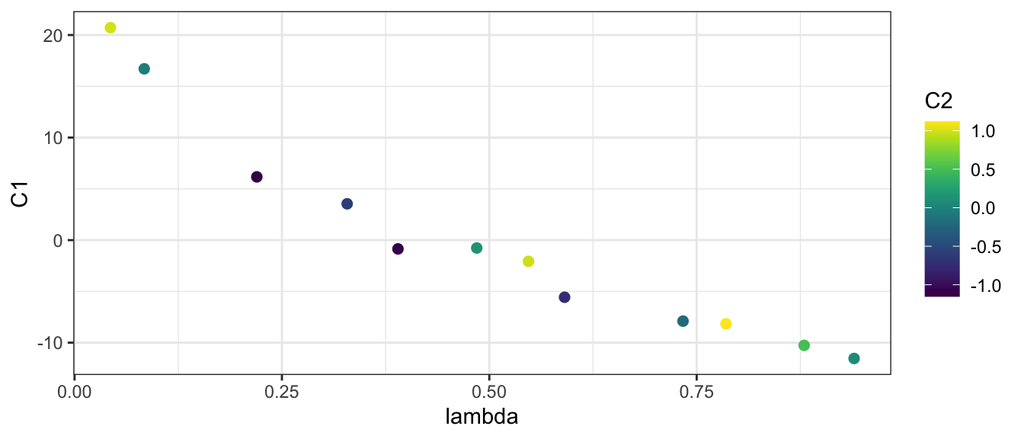

```r
PlotPair(tData_coeffs, 'lambda', 'C1', col = 'C2')
```

Training emulators, and thereafter prediction, validation and all other tasks, proceed in a similar way in terms of the code. The emulators are now trained to the first 4 coefficients, which are already paired with the inputs in `tData_coeffs`. Note that we don’t need to explicitly provide which columns to emulate here, as the default behaviour of `FitEmulators` is to search for a column named `C1`, treat this as the first output to emulate, and emulate all subsequent columns:

```r
em_coeffs <- FitEmulators(tData_coeffs[train_inds,], input = c('lambda','C'))
```

4 emulators have been trained, one for each coefficient:

```r
summary(em_coeffs)
```

```
##      Length Class  Mode
## [1,] 5      -none- list
## [2,] 5      -none- list
## [3,] 5      -none- list
## [4,] 5      -none- list
```

```r
unlist(lapply(1:length(em_coeffs), function(k) em_coeffs[[k]]$response))
```

```
## [1] "C1" "C2" "C3" "C4"
```

```r
loo_coeffs <- LeaveOneOut(em_coeffs, by_index = TRUE)
```

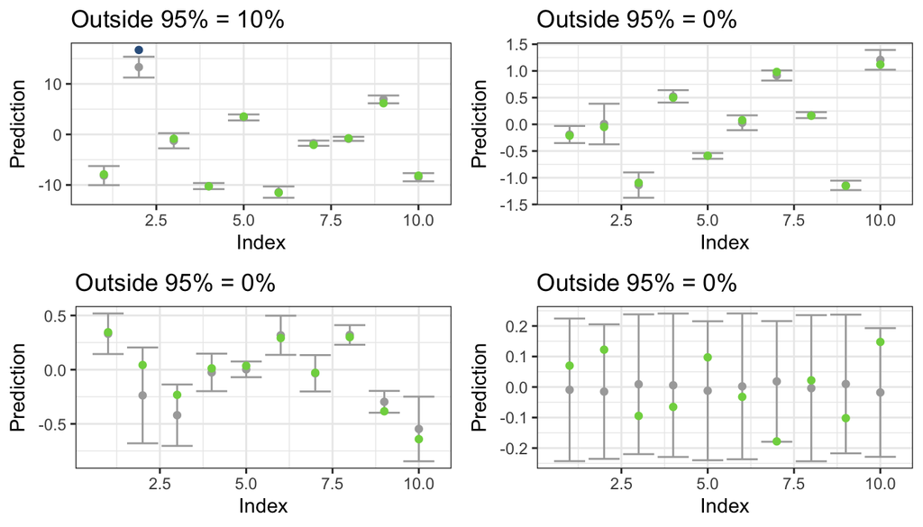

The first 3 emulators seem to have some predictive ability. The 4th appears to be noise - each prediction is fairly close to zero, with a similar variance. We can probably not bother emulating this coefficient, and treat it as noise.

As before, we can directly use `PlotSamples` to predict and sample from the emulator. We could also create the sample by hand, instead using function `BasisEmSamples` in place of the independent sampling code from before.

Predicting and sampling for the 2 validation points, indicated by `data_inds = val_inds`:

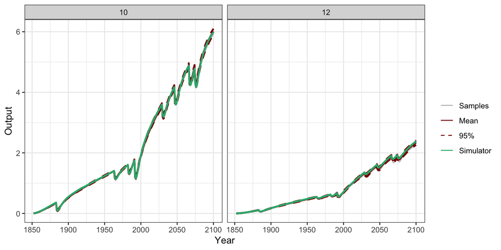

```r
PlotSamples(DataBasis, design = tData_coeffs[val_inds,], emulator = em_coeffs, data_inds = val_inds, sample_inds = 1:10)
```

Zooming in as before, we see broadly similar behaviour, although now the samples are smoother and look more like realisations of the EBM simulator itself. This is because the sampling is now on the coefficient level, with each sample of coefficients then mapped through the basis to produce the full 1850-2100 curve, and hence each sample incorporates the patterns from the basis (and hence from the EBM):

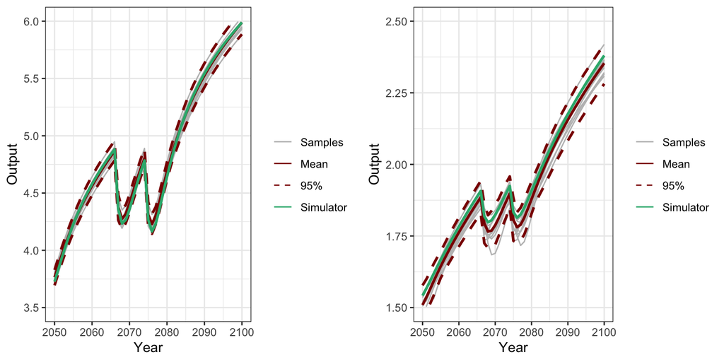

```r
plot1 <- PlotSamples(DataBasis, design = tData_coeffs[val_inds[1],], emulator = em_coeffs, data_inds = val_inds[1], sample_inds = 1:10) +
  xlim(2050,2100) + ylim(3.5,6)
plot2 <- PlotSamples(DataBasis, design = tData_coeffs[val_inds[2],], emulator = em_coeffs, data_inds = val_inds[2], sample_inds = 1:10) +
  xlim(2050,2100) + ylim(1.5,2.5)
cowplot::plot_grid(plot1, plot2)
```

For a direct comparison, plotting the different approaches alongside each other (left = independent, right = dimension reduction). 1st validation point:

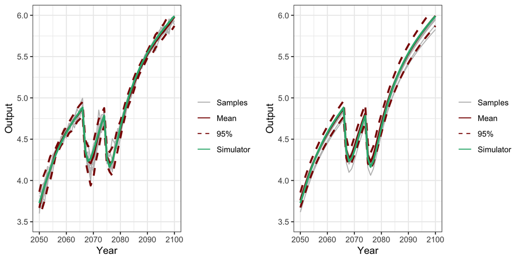

```r
plot1 <- PlotSamples(DataBasis, design = design[val_inds[1],], emulator = em_all, data_inds = val_inds[1], sample_inds = 1:10) +
  xlim(2050,2100) + ylim(3.5,6)
plot2 <- PlotSamples(DataBasis, design = tData_coeffs[val_inds[1],], emulator = em_coeffs, data_inds = val_inds[1], sample_inds = 1:10) +
  xlim(2050,2100) + ylim(3.5,6)
cowplot::plot_grid(plot1, plot2)
```

2nd validation point:

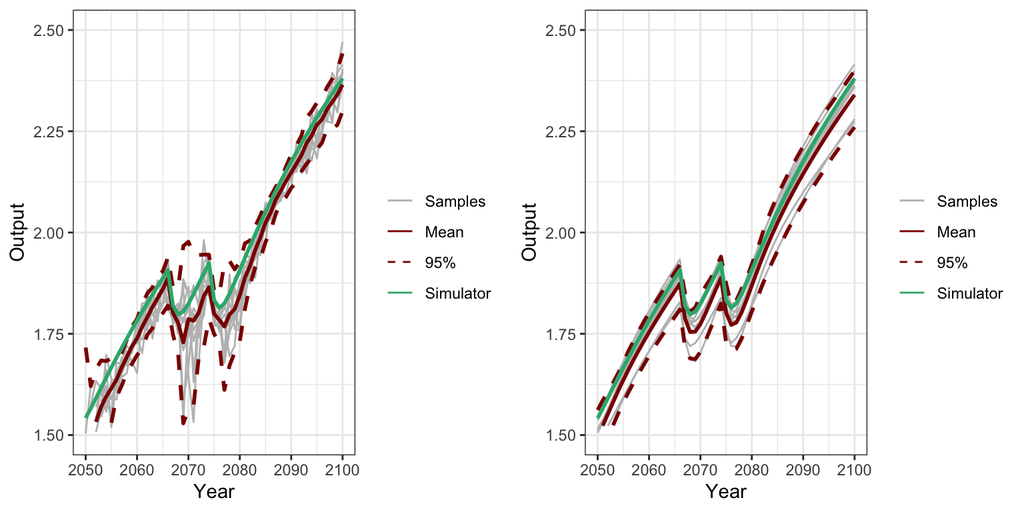

```r
plot1 <- PlotSamples(DataBasis, design = design[val_inds[2],], emulator = em_all, data_inds = val_inds[2], sample_inds = 1:10) +
  xlim(2050,2100) + ylim(1.5,2.5)
plot2 <- PlotSamples(DataBasis, design = tData_coeffs[val_inds[2],], emulator = em_coeffs, data_inds = val_inds[2], sample_inds = 1:10) +
  xlim(2050,2100) + ylim(1.5,2.5)
cowplot::plot_grid(plot1, plot2)
```

Broadly, the mean and uncertainty are similar, with the difference between the samples addressed above.

There’s some interesting differences:

- For 2080 onwards (i.e., beyond any effects of volcanic forcing), the independent emulation approach has lower uncertainty.
- Around the volcanic forcings, the basis approach has lower uncertainty.

This is not too surprising: if the only information we have is a particular year, where there’s both signal from the model inputs and some volcanic event, the response being noisier seems reasonable. However, the basis approach is able to capture this more accurately (partly because being handled separately to the main signal, via `C2`, `C3`, so easier to capture specific effects from the inputs relating to this; and partly because there may be information across different years that give information about the volcanic feedbacks - which is shown by the relationship in the 2nd, 3rd basis vectors).

Once the volcanic signal has dampened and all the temperature signal is coming from `lambda`, `C` again, emulating a specific year only is unsurprisingly better (basis approach has fewer degrees of freedom, only 4 GPs), but with the trade-off that do worse when there is useful information from other years, and that don’t have realistic-looking samples from the emulator.

## History matching

Now let’s compare to observations.

For this model, the output is relatively predictable and easy to emulate, and so even when only using 10 simulations to train emulators we get predictions very close to the actual EBM output already. To give a better illustration of the typical iterative procedure, we’ll start by using even fewer training points to fit our emulators at ‘wave 1’, and refine them from there.

### Single output

Imagine we want to calibrate to the present-day temperature (anomaly). To do so, we might take the average across 2016-2025 (e.g., to avoid overfitting to a particular year).

To allow comparison between our ‘observation’ for 2016-2025 and the EBM, we’ll train an emulator for this output. Summarising the PPE output across 2016-2025:

```r
temp2025 <- ppe[which(years_all %in% 2016:2025), ]
temp2025 <- apply(temp2025, 2, mean)
temp2025
```

```
##  [1] 1.0890530 2.8419641 1.4531197 0.9446995 1.8455698 0.8419788 1.5639668
##  [8] 1.6274075 1.9356989 3.2257467 1.1091173 1.1842621
```

Training an emulator using the first 4 simulations only as training data:

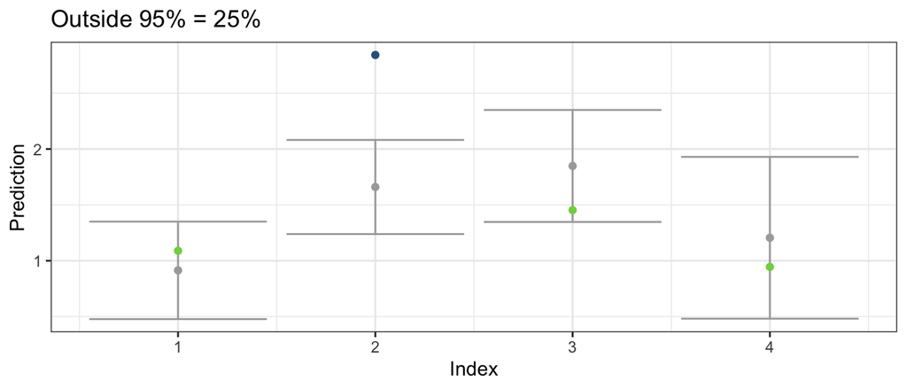

```r
tData2025 <- data.frame(design, temp2025)
em2025 <- FitEmulators(tData2025[1:4,])
LeaveOneOut(em2025, by_index = TRUE)
```

Trained on only 4 points, the emulator is understandably uncertain. It’s somewhat hard to judge whether this is a suitable emulator or not, although at least the uncertainty seems quite large, as we’d hope. Training to only 4 points is not a realistic scenario, so let’s just treat this as ‘fine’ and move on in our illustrative example.

Given an emulator, we usually want to predict the output, and hence calculate implausibility, for a large space-filling design in the input space, usually given by a Latin hypercube:

```r
set.seed(303)
Xpred <- lhs::randomLHS(5000, 2)
colnames(Xpred) <- colnames(design)
```

To calibrate, we need an observed value, $z$, of the 2016-2025 average temperature anomaly; an observation error variance; and a discrepancy variance.

In lieu of ‘real’ observations, we could interpret this procedure as searching for simulations that are within some tolerance of a chosen value $z$. E.g., is it possible for the EBM to produce a present day anomaly of 2.5 degrees?

The function `HistoryMatch` is a general wrapper for history matching to a single output, across multiple independent outputs, and across high-dimensional, correlated spatial and/or temporal outputs. Overall, we need to provide an emulator that will provide predictions of the simulator, corresponding to what we have observations of. So here, we’re calibrating to a 2016-2025 temperature anomaly of 2.5, using the emulator we fitted above:

```r
hm2025 <- HistoryMatch(emulator = em2025, design = Xpred, Obs = 2.5, ObsVar = 0.01, DiscVar = 0)
summary(hm2025)
```

```
##           Length Class      Mode
## Impl      5000   -none-     numeric
## threshold    1   -none-     numeric
## NROY         1   -none-     numeric
## Pass_kth     1   -none-     numeric
## Pass_N       2   -none-     numeric
## inNROY    5000   -none-     logical
## Design       3   data.frame list
## Preds        2   -none-     list
## wave         1   -none-     numeric
```

There’s many outputs here:

- `$Design` is the same as the given design, but with a column appended indicating whether each point is in NROY space or not.
- `$Preds` contains the emulator predictions at the given design, so as usual contains components `$Expectation` and `$Variance`.
- The other outputs all relate to the calibration part:

```r
# Implausibility corresponding to each row of Design (Xpred)
head(hm2025$Impl)
```

```
##           [,1]
## [1,] 3.6218212
## [2,] 0.6600387
## [3,] 1.3706790
## [4,] 3.6474980
## [5,] 0.9897343
## [6,] 4.3913952
```

```r
# Proportion of space not ruled out
hm2025$NROY
```

```
## [1] 0.6282
```

```r
# Proportion of space that satisfies the kth constraint. As there's just 1 here, same as $NROY
hm2025$Pass_kth
```

```
## [1] 0.6282
```

```r
# Proportion of space that passes N out of k constraints
hm2025$Pass_N
```

```
##      0      1
## 0.3718 0.6282
```

```r
# Whether each row of design is in NROY
head(hm2025$inNROY)
```

```
## [1] FALSE  TRUE  TRUE FALSE  TRUE FALSE
```

So, after wave 1 63% of the 2D input space is not ruled out yet (NROY).

Plotting the resulting NROY space, with the 4 training points added as red circles:

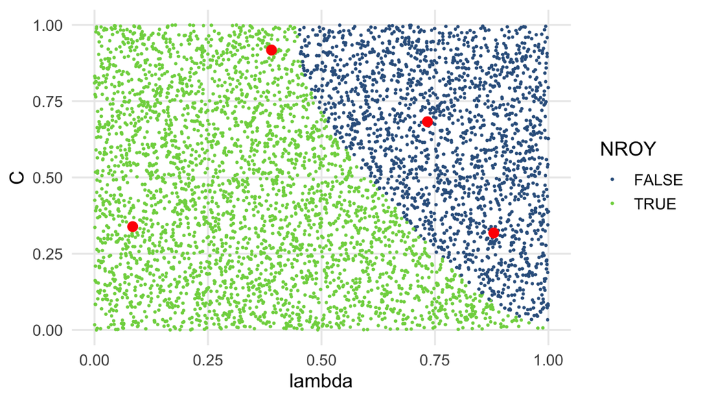

```r
PlotNROY(hm2025$Design, k = 1:2) +
  theme_minimal(base_size = 14) +
  theme(panel.grid.minor = element_blank(),
        strip.text = element_text(face = "bold")) +
  geom_point(data = tData2025[1:4,], aes(x = lambda, y = C), col = 'red', size = 3)
```

We can see that we’ve generally ruled out simulations where both `C` and `lambda` are high, but have retained the majority of input space, likely because our emulator is relatively uncertain, rather than because all of these input pairs do actually lead to a temperature anomaly very close to 2.5. So, let’s iterate!

The next step is to generate a new design within the current NROY space, run these new simulations using the EBM, and refit emulators and repeat the history matching procedure. Usually we want to approach the design of new waves in a sensible way. A good starting point is a space-filling sample from NROY space (see function `NewDesign`), but particularly as the NROY space becomes smaller, other approaches may be better.

To begin with, though, as an illustration I’m just going to add the 5th and 7th points from our original PPE. Based on their inputs, they’re fairly central in the current NROY space, so let’s add these and see what happens.

Often we’ll only train emulators for the new batch, or ‘wave’, of simulations, as we only require the emulator to be accurate in the region of input space we care about, i.e. NROY space, in order to further reduce this. Sometimes keeping points from outside NROY space can lead to a more accurate emulator, particularly around the edges of NROY. As a default assumption, it’s fine to just use the points in NROY (i.e., the full new design, plus any from the previous wave that are in NROY), and add in other points from previous waves only if needed. Not having to capture the behaviour across the full input space is usually beneficial, as there may be very weird, nonstationary behaviour in some parts. If we’ve already ruled these out, we don’t have to waste time trying to fit an emulator that can capture these parts!

All that said, because my new wave is only 2 points, I’ll fit an emulator to all 6 points I’ve seen so far across wave 1 and 2:

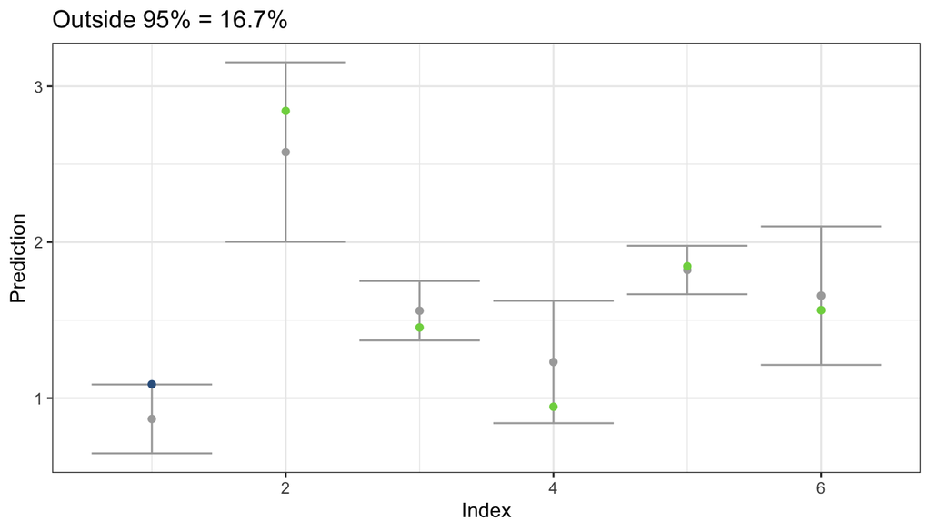

```r
em2025_W2 <- FitEmulators(tData2025[c(1:5,7),])
LeaveOneOut(em2025_W2, by_index = TRUE)
```

It seems like we’ve generally reduced the emulator uncertainty, particular for points 1, 3 and 5.

Given our updated emulator, now we history match again. Instead of providing a large space-filling design, we can instead provide `HistoryMatch` with the previous wave, so that we already have a sample from the wave 1 NROY space as a starting point for evaluating the wave 2 emulator (if points were ruled out at wave 1, no need to consider them at wave 2):

```r
hm2025_W2 <- HistoryMatch(emulator = em2025_W2, PreviousWave = hm2025, Obs = 2.5, ObsVar = 0.01, DiscVar = 0)
hm2025_W2$NROY
```

```
## [1] 0.2236
```

We’ve gone from 62% to 22%, thanks to our emulator now having much lower variance than before.

Note that `$Design` now contains 2 columns with NROY indicators, 1 for each wave (where all those with FALSE at wave 1 are necessarily FALSE at wave 2 as well):

```r
head(hm2025_W2$Design)
```

```
##      lambda         C NROY1 NROY2
## 1 0.5533850 0.9412921 FALSE FALSE
## 2 0.1002113 0.3326906  TRUE  TRUE
## 3 0.2103844 0.9625225  TRUE FALSE
## 4 0.6230702 0.6340809 FALSE FALSE
## 5 0.4665206 0.1770336  TRUE FALSE
## 6 0.9318968 0.7574090 FALSE FALSE
```

Plotting our new NROY space (where the code will automatically use the final column as the NROY indicator, hence we get the wave 2 space by default):

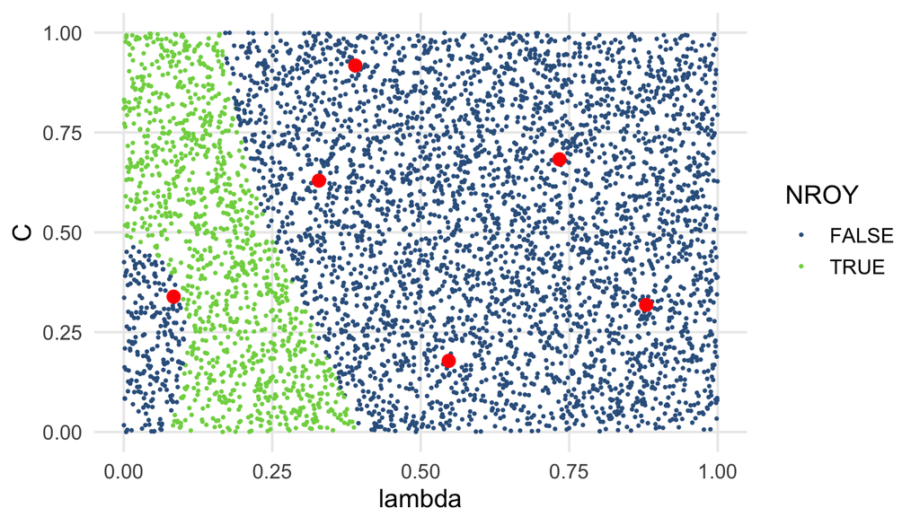

```r
PlotNROY(hm2025_W2$Design, k = 1:2) +
  theme_minimal(base_size = 14) +
  theme(panel.grid.minor = element_blank(),
        strip.text = element_text(face = "bold")) +
  geom_point(data = tData2025[c(1:5,7),], aes(x = lambda, y = C), col = 'red', size = 3)
```

To demonstrate other aspects of the code, and to finish things off more quickly, let’s draw a larger number of samples from NROY space, run the EBM at these points, and perform another wave of history matching, to hopefully reduce the input space further.

In `hm2025_W2`, we have a set of points that is currently in NROY. Extracting these:

```r
CandPoints <- subset(hm2025_W2$Design, NROY2)
dim(CandPoints)
```

```
## [1] 1118    4
```

This is a set of over 1000 samples from the current NROY space.

Imagine we want to run 10 new simulations of the EBM. We could select 10 points at random from this NROY space, and in 2D and with the predictability of this model, this will probably work fine. A more general approach would be to instead try to select a set of 10 points from the above 1000+ that best spans the NROY space (space-filling):

```r
set.seed(439)
design_W3 <- NewDesign(CandPoints, n_new = 10)
design_W3
```

```
## $design
##        lambda          C
## 1  0.32706511 0.13813905
## 2  0.13954837 0.74648887
## 3  0.10702628 0.96399080
## 4  0.09876578 0.65740544
## 5  0.09234097 0.54039365
## 6  0.22902478 0.34937892
## 7  0.22437631 0.54048453
## 8  0.19361767 0.05610351
## 9  0.17974705 0.27785435
## 10 0.25207058 0.20732257
##
## $inds
##  [1]  884  576 1032  200   75  700  546  249  370  697
```

If we overlay these on the previous NROY plot as triangles:

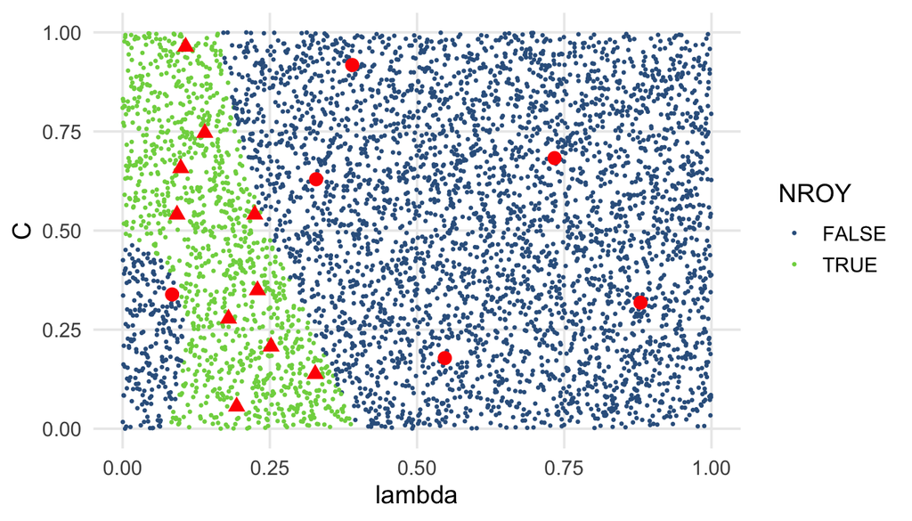

```r
PlotNROY(hm2025_W2$Design, k = 1:2) +
  theme_minimal(base_size = 14) +
  theme(panel.grid.minor = element_blank(),
        strip.text = element_text(face = "bold")) +
  geom_point(data = tData2025[c(1:5,7),], aes(x = lambda, y = C), col = 'red', size = 3) +
  geom_point(data = design_W3$design, aes(x = lambda, y = C), col = 'red', size = 3, shape = 17)
```

By construction, they all lie within the current NROY space, and seem to be relatively space-filling. At least, none of the points are very close to each other, and they cover most areas of space (perhaps a bit of a gap in the top left).

The workflow now requires running new simulations of the EBM, evaluating our ‘expensive’ model to these 10 sets of inputs:

```r
ppe_W3 <- ebm_output(design_W3$design)
dim(ppe_W3)
```

```
## [1] 251  10
```

```r
# Calculating 2016-2025 mean
temp2025_W3 <- ppe_W3[which(years_all %in% 2016:2025), ]
temp2025_W3 <- apply(temp2025_W3, 2, mean)
temp2025_W3
```

```
##  [1] 2.164460 2.128523 1.858930 2.358096 2.547874 2.353479 2.184061 2.654541
##  [9] 2.570224 2.375112
```

As we would hope, the new simulations cover a narrower range than the entire ensemble spread, and are generally closer to the observation of 2.5 than our original set of samples was. This should be the case if things have worked as intended: points that are in NROY space should lead to output closer to the observations, unless emulator variance is large, or our emulator was biased/inaccurate in some way.

Refitting our emulator:

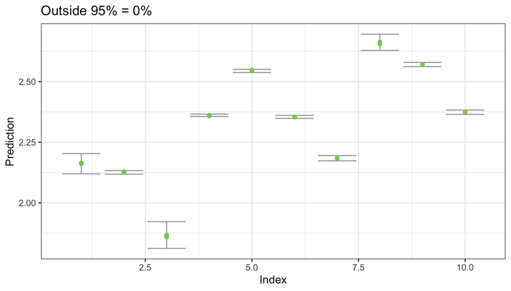

```r
tData2025_W3 <- data.frame(design_W3$design, temp2025_W3)
em2025_W3 <- FitEmulators(tData2025_W3)
LeaveOneOut(em2025_W3, by_index = TRUE)
```

Emulator variance is much lower than previously (note narrower y axis than before). This should usually be the case: as we rule out space/zoom in towards the observations, the subsequent waves have a greater density of training points in the region around the observations, and so generally the emulator should be more accurate and confident in this region.

Wave 3 of history matching:

```r
hm2025_W3 <- HistoryMatch(emulator = em2025_W3, PreviousWave = hm2025_W2, Obs = 2.5, ObsVar = 0.01, DiscVar = 0)
hm2025_W3$NROY
```

```
## [1] 0.1496
```

Despite a much more accurate emulator, we’ve ‘only’ reduced to 15% of space:

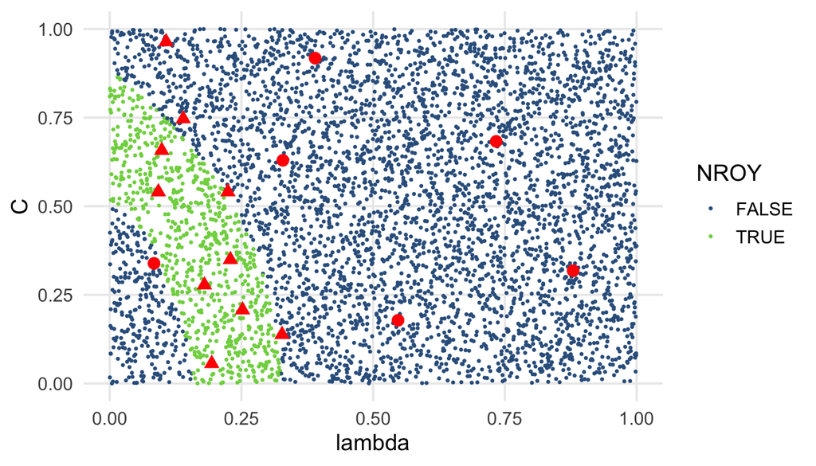

```r
PlotNROY(hm2025_W3$Design, k = 1:2) +
  theme_minimal(base_size = 14) +
  theme(panel.grid.minor = element_blank(),
        strip.text = element_text(face = "bold")) +
  geom_point(data = tData2025[c(1:5,7),], aes(x = lambda, y = C), col = 'red', size = 3) +
  geom_point(data = design_W3$design, aes(x = lambda, y = C), col = 'red', size = 3, shape = 17)
```

However, 6 of the 10 simulations at this wave had output within 2SD of the observations, so in fact we’re likely just converging to something very close to the ‘true’ NROY space (i.e., that would be given if we perfectly knew the model output at every input). We could run another wave, and would likely see that we fail to reduce emulator variance by much more, and that therefore we rule out very little or no additional space, which is a sign that we can stop iterating.

Since the EBM is very fast to run, we can illustrate the ‘true’ NROY space by evaluating the EBM at the 5000 points we used above:

```r
ppe_5000 <- ebm_output(Xpred)
temp2025_5000 <- ppe_5000[which(years_all %in% 2016:2025), ]
temp2025_5000 <- apply(temp2025_5000, 2, mean)
```

We can still use the `HistoryMatch` function, by providing `TrueOutput` instead of an emulator:

```r
hm2025_true <- HistoryMatch(emulator = NULL, design = Xpred, TrueOutput = temp2025_5000, Obs = 2.5, ObsVar = 0.01, DiscVar = 0)
hm2025_true$NROY
```

```
## [1] 0.149
```

So in fact, the true NROY space consists of 14.9% of input space, which is extremely similar to our results above using the emulator! And plotting, we have basically the same NROY space:

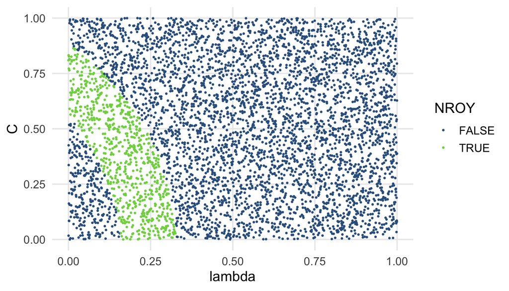

```r
PlotNROY(hm2025_true$Design, k = 1:2) +
  theme_minimal(base_size = 14) +
  theme(panel.grid.minor = element_blank(),
        strip.text = element_text(face = "bold"))
```

### Identifying misspecified errors

As an aside, what happens if we instead had set the observation $z$ at, say, 5?

Going back to the original design/emulator:

```r
hm2025_z5 <- HistoryMatch(emulator = em2025, design = Xpred, Obs = 5, ObsVar = 0.01, DiscVar = 0)
```

Given this observation, and specified error tolerances, the whole input space is ruled out:

```r
hm2025_z5$NROY
```

```
## [1] 0
```

```r
summary(hm2025_z5$Impl)
```

```
##        V1
##  Min.   : 3.475
##  1st Qu.: 6.531
##  Median : 8.567
##  Mean   : 8.376
##  3rd Qu.:10.286
##  Max.   :12.009
```

If we’re satisfied that the emulator is accurately capturing uncertainty, this result immediately tells us that the simulator is unable to produce $z = 5$ to within the required tolerance, for any choice of inputs.

If this really were the ‘observation’, and if our observation error variance really were 0.01, ruling everything out tells us about model discrepancy, and that we need to change our assumption about this term, currently (incorrectly) set as zero, as clearly there is a mismatch between the simulator and reality.

### Multiple metrics

We can work with multiple outputs/summaries/metrics at the same time in a similar way to the above, calculating the implausibility for each metric individually, and ruling out inputs based on the k-max implausibility.

The difference between this and the following section is that here the outputs are being treated independently, and we’re generally considering a small number of summaries of a larger output field, rather than the full output (where independence may be less appropriate).

Here, we’ll calibrate to the temperature anomaly for a set of years: 1950, 1975, 2000 and 2025. We already have emulators for each of these years, but refitting these here:

```r
tData_years <- data.frame(design,
                          t(ppe[which(years_all %in% c(1950,1975,2000,2025)),]))
colnames(tData_years)[3:6] <- c('T1950', 'T1975', 'T2000', 'T2025')
em_years <- FitEmulators(tData_years, input = c('lambda','C'), output = c('T1950', 'T1975', 'T2000', 'T2025'))
loo_years <- LeaveOneOut(em_years, by_index = TRUE)
```

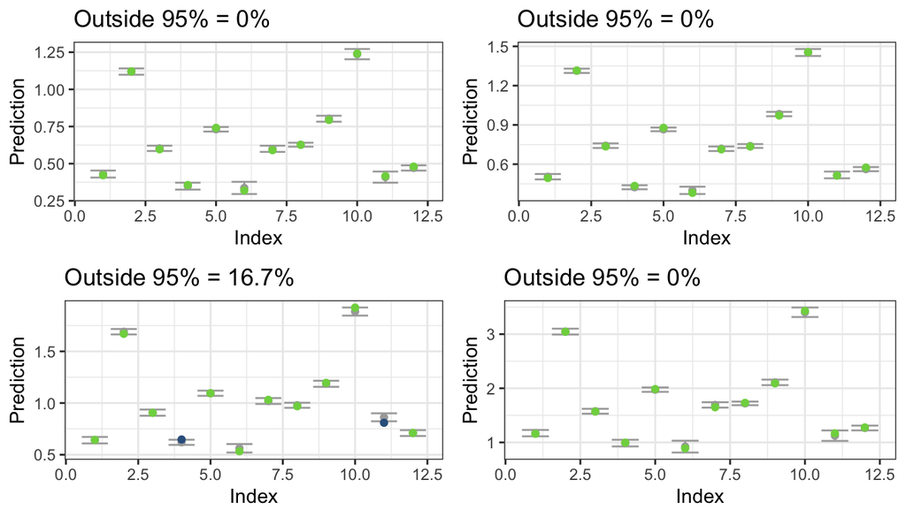

Let’s imagine we have observations for each of these 4 years, say $\textbf{z} = (0.2,1.2,1.5,2)$. We also need to provide an observation error variance and discrepancy for each of these 4 outputs. Let’s use the same observation error and discrepancy variance as before.

The history matching code is almost identical to before:

```r
hm_years <- HistoryMatch(emulator = em_years, design = Xpred, Obs = c(0.2,1.2,1.5,2), ObsVar = 0.01, DiscVar = 0)
```

All that’s changed in the function call is that now `Obs` is a vector of values, corresponding to the 4 emulated outputs in `em_years`.

There are some other hidden changes/assumptions:

- `ObsVar` is given as a single value here, which is interpreted as each output has the same observation error variance. In reality this may be different by output, and so this could be provided as a 4-length vector instead.
- `DiscVar` works in the same way as `ObsVar`: either needs to be a common value for all outputs, or a specific value for each needs to be given.
- An implausibility is now calculated for each row of `Xpred`, for each of the 4 outputs:

```r
dim(hm_years$Impl)
```

```
## [1] 5000    4
```

```r
head(hm_years$Impl)
```

```
##          [,1]      [,2]     [,3]      [,4]
## [1,] 2.915336 6.0787737 7.615384  7.000387
## [2,] 9.025225 0.8956027 1.505849  9.894365
## [3,] 5.052571 2.7191008 3.711122  1.658500
## [4,] 2.932146 6.1676991 7.462534  6.357849
## [5,] 4.737890 3.9442578 3.581903  1.242888
## [6,] 1.170335 8.1664970 9.724315 11.001061
```

- `$Pass_kth` is now more useful than previously, providing the proportion of inputs that are not ruled out according to each of the 4 metrics individually. This is useful for checking whether there are particular metrics that provide an extremely strong or weak constraint, whether this is because the observations are inconsistent with the simulator, because emulator variance is extremely large, because the model spread is small relative to the observation error, or some other reason:

```r
hm_years$Pass_kth
```

```
## [1] 0.3836 0.3272 0.2920 0.2372
```

- Similarly `$Pass_N` is also more useful, as this tells us what proportion of inputs satisfy 0/4, 1/4, 2/4, 3/4 and 4/4 constraints. Here, we see that the best we can do is match 3/4: although each of the 4 metrics can be satisfied by at least 23% of parameter space, there is no overlap between all 4 of the individual NROY spaces:

```r
hm_years$Pass_N
```

```
##      0      1      2      3
## 0.1604 0.5192 0.2404 0.0800
```

And hence:

```r
hm_years$NROY
```

```
## [1] 0
```

With multiple outputs, we might instead be more conservative, and instead of requiring all implausibilities to be below 3 to classify a given input as NROY, we could instead use the 2nd highest implausibility value at an input to classify points as NROY or not - which is equivalent to requiring 3/4 to be below 3. Re-running the code with this set as the definition of NROY space, the result should be 8%:

```r
hm_years <- HistoryMatch(emulator = em_years, design = Xpred, Obs = c(0.2,1.2,1.5,2), ObsVar = 0.01, DiscVar = 0, kmax = 2)
hm_years$NROY
```

```
## [1] 0.08
```

Plotting is done in the same way:

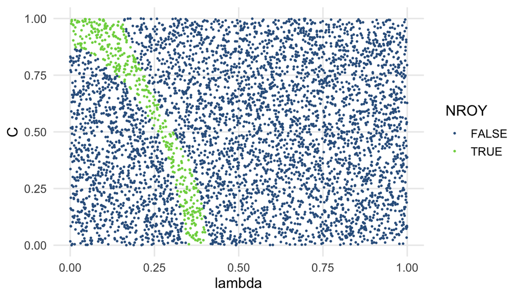

```r
PlotNROY(hm_years$Design, k = 1:2) +
  theme_minimal(base_size = 14) +
  theme(panel.grid.minor = element_blank(),
        strip.text = element_text(face = "bold"))
```

(Looks somewhat similar to the part of parameter space highlighted in the 1D case. This is a coincidence: I chose the ‘observations’ so that they lie within the ensemble spread, but somewhat at random.)

Perhaps more usefully, we should explore why we can’t satisfy all 4 constraints at once, e.g., what parts of input space satisfy different constraints? What do simulations look like that fail on 1?

For example, plotting the part of space that is below implausibility 3 for each of the 4 observations in turn, by providing these classifications explicity to `PlotNROY`:

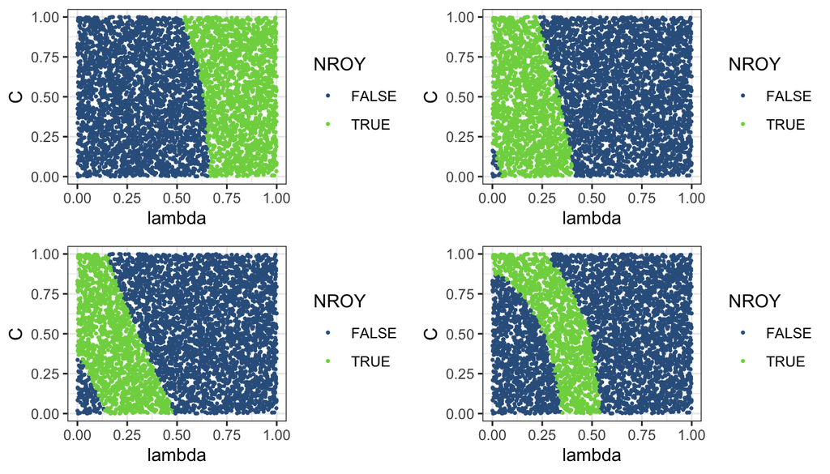

```r
plot1 <- PlotNROY(hm_years$Design, k = 1:2, NROY = hm_years$Impl[,1] < 3)
plot2 <- PlotNROY(hm_years$Design, k = 1:2, NROY = hm_years$Impl[,2] < 3)
plot3 <- PlotNROY(hm_years$Design, k = 1:2, NROY = hm_years$Impl[,3] < 3)
plot4 <- PlotNROY(hm_years$Design, k = 1:2, NROY = hm_years$Impl[,4] < 3)
cowplot::plot_grid(plot1, plot2, plot3, plot4)
```

We see that, given the current tolerances, we require completely different parts of input space in order to get close to the ‘observation’ for 1950 (top left plot) and any of the others.

### High-dimensional outputs

Instead, we could calculate the multivariate version of the implausibility for the full, higher dimensional output, using the emulators fitted earlier via dimension reduction. The emulator variance (when mapped to the original field) is correlated, as seen by the structure of the samples, so we should account for this in the implausibility. The observation error and discrepancy covariance matrices may also contain correlations.

We need to set ‘observations’. Here, I’ll choose the 10th member of the original ensemble (which was not used when training the emulators), and add some uncorrelated Gaussian noise. We’ll also only ‘observe’ up to the present day (let’s call this 2025):

```r
set.seed(548392)
obs_inds <- which(years_all <= 2025)
obs <- ppe[obs_inds,10] + rnorm(length(obs_inds), 0, sd = sqrt(0.1))
```

Adding this curve on top of the original PPE:

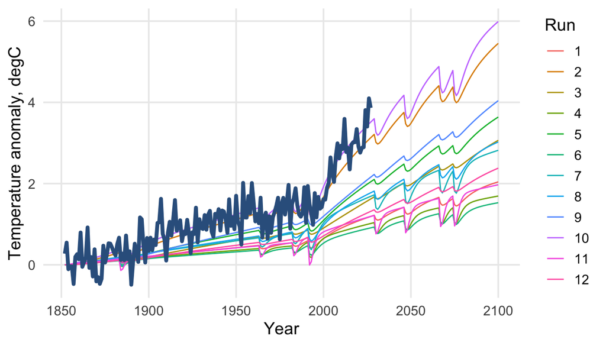

```r
PlotData(DataBasis, Obs = obs) +
  theme_minimal(base_size = 14) +
  theme(panel.grid.minor = element_blank(),
        strip.text = element_text(face = "bold")) +
  labs(col = 'Run', y = 'Temperature anomaly, degC')
```

It looks fairly different from the EBM output, which is smooth except when there is volcanic forcing. However, this sort of noisy curve is much more representative of real observations (see e.g., https://berkeleyearth.org/global-temperature-report-for-2025/).

In order to history match to the full output for 1850-2025, we require an emulator that predicts the simulator output for the same time period. We’ll use the basis emulator we fitted earlier, `em_coeffs`, and given this, we can use the `HistoryMatch` function to calculate implausibilities given observations and an error specification (observation error, discrepancy, which are both now covariance matrices). We also need to provide a `DataBasis` object that relates to the emulated coefficients:

```r
try(hm_full <- HistoryMatch(emulator = em_coeffs, DataBasis = DataBasis, design = Xpred, Obs = obs, ObsVar = 0.1, DiscVar = 0))
```

```
## Error in HistoryMatch(emulator = em_coeffs, DataBasis = DataBasis, design = Xpred,  :
##   Inconsistency between number of observations and size of field. Either provide observations for full field, or select indices of full field that correspond to the observations via obs_inds.
```

Running this should generate an error, because the dimension of the observations (only up to 2025) is inconsistent with the dimension of the model output (up to 2100).

It’s fine to only observe a subset of the full model output. All we need to do is use `obs_inds` to select which of the model output indices correspond to the observations:

```r
hm_full <- HistoryMatch(emulator = em_coeffs, DataBasis = DataBasis, design = Xpred, Obs = obs, ObsVar = 0.1, DiscVar = 0, obs_inds = obs_inds)
hm_full$NROY
```

```
## [1] 0.0362
```

And now everything runs fine, and we’ve reduced to 3.6% of input space.

Again, I’ve used a shortcut to define the observation error variance. If given a constant `ObsVar`, the code will assume this means an iid variance across all outputs. Here, iid noise was used to define the observations, so this is consistent with the setup for our ‘observations’.

We could alternatively provide a covariance matrix across the observations. Let’s do so, to demonstrate that the code is working as intended:

```r
hm_full_v2 <- HistoryMatch(emulator = em_coeffs, DataBasis = DataBasis, design = Xpred, Obs = obs, ObsVar = 0.1*diag(length(obs)), DiscVar = 0, obs_inds = obs_inds)
```

The calculated implausibilities should be identical:

```r
summary(hm_full$Impl - hm_full_v2$Impl)
```

```
##    Min. 1st Qu.  Median    Mean 3rd Qu.    Max.
##       0       0       0       0       0       0
```

Success!

Plotting the NROY space we’ve defined, now additionally using option `Truth` as we generated the observations using a known simulation of the EBM, so can use this as a check that our NROY space contains the true input setting:

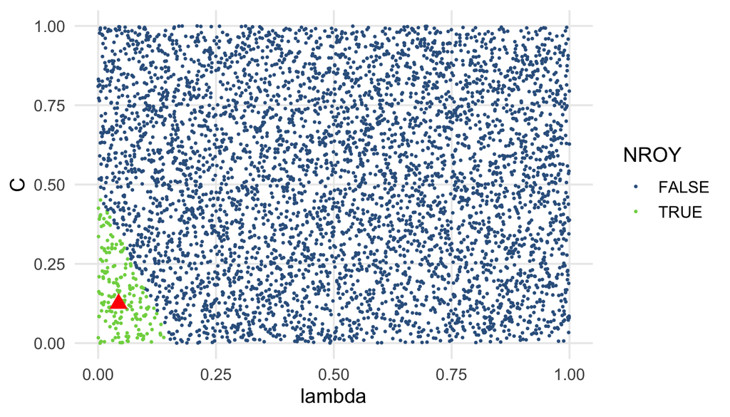

```r
PlotNROY(hm_full$Design, k = 1:2, Truth = design[10,]) +
  theme_minimal(base_size = 14) +
  theme(panel.grid.minor = element_blank(),
        strip.text = element_text(face = "bold"))
```

And it does. We deliberately picked a fairly extreme simulation to base the observations around, so it’s not surprising that the NROY is quite small, and towards the corner of parameter space.

We could sample from this NROY space and perform additional waves as before, perhaps adding different observational metrics if they’re available.

Running the EBM at all of the above samples that are in NROY:

```r
ppe_full <- ebm_output(subset(hm_full$Design, NROY1))
```

Let’s process and plot this new set of simulations:

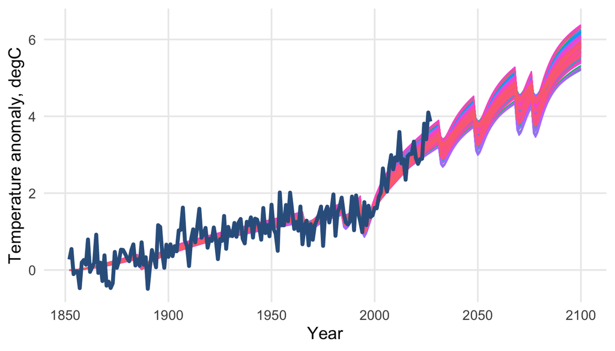

```r
DataBasis_new <- MakeDataBasis(ppe_full)
DataBasis_new$grid <- DataBasis$grid
PlotData(DataBasis_new, Obs = obs) +
  theme_minimal(base_size = 14) +
  theme(panel.grid.minor = element_blank(),
        strip.text = element_text(face = "bold"),
        legend.position = 'none') +
  labs(y = 'Temperature anomaly, degC')
```

This set of simulations seems to track the observations quite closely (bearing in mind that they are the model output, absent any observational noise, so won’t replicate the random year-to-year variability).

We could use the ensemble spread for 2026 onwards as a representation of our uncertainty of future temperature. At least, to some extent: it doesn’t represent all uncertainty, as it’s conditional on a particular volcanic forcing, which is of course itself uncertain.

We could generate more realistic future trajectories by adding observational noise (assuming we’re happy to assume this continues to be iid with the same variance in the future):

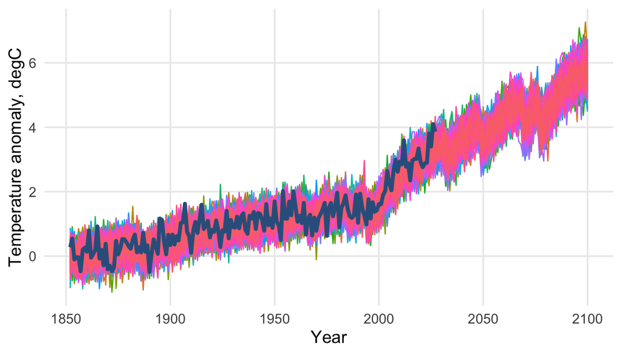

```r
ppe_full_noise <- ppe_full + matrix(rnorm(nrow(ppe_full)*ncol(ppe_full), 0, sd = sqrt(0.1)), nrow(ppe_full), ncol(ppe_full))
DataBasis_noise <- MakeDataBasis(ppe_full_noise)
DataBasis_noise$grid <- DataBasis$grid
PlotData(DataBasis_noise, Obs = obs) +
  theme_minimal(base_size = 14) +
  theme(panel.grid.minor = element_blank(),
        strip.text = element_text(face = "bold"),
        legend.position = 'none') +
  labs(y = 'Temperature anomaly, degC')
```

Probably a better, less unrealistically-confident set of projections. Still ignoring boundary condition uncertainty, and of course here we’ve assumed zero discrepancy, which is unlikely the case in real examples, and we’d need to account for this in some way.

Still probably not perfect: tend to underestimate the more recent observations slightly. Is this indicative of a changing trend?

### High-dimensional + emulate all

We could of course also use our set of independent emulators to calculate the multivariate implausibility: we have a vector of expectations, and can convert the vector of variances into a matrix by setting these as the diagonal elements (with zeros off-diagonal due to the independence assumption).

If the observation error and discrepancy matrices are also diagonal, this will still be reasonably efficient, but in general an $\ell \times \ell$ inversion is required for each input.

We can calculate this implausiblity in a similar way to previously, by providing the set of independent emulators, 1 for each provided observation. Recall that we ignored 1850 and 1851 in `em_all`, hence we’ll also remove these from the observations:

```r
em_inds <- which(years_all[-c(1:2)] %in% 1852:2025)
hm_full <- HistoryMatch(emulator = em_all[em_inds], design = design[val_inds,], Obs = obs[-c(1:2)], ObsVar = 0.1, DiscVar = 0)
dim(hm_full$Impl)
```

```
## [1]   2 174
```

The default behaviour when the number of emulators is the same as the number of observations is to calculate the 1D implausibility, so here we have 174 different implausiblities, one for each observation 1852-2025.

As a check and demonstration of what the code is calculating here, using the previously calculated expectation and variance to calculate the implausibility for these two inputs by hand:

```r
abs(obs[-c(1:2)]-preds$Expectation[1,em_inds]) / sqrt(preds$Variance[1,em_inds]+0.1)
abs(obs[-c(1:2)]-preds$Expectation[2,em_inds]) / sqrt(preds$Variance[2,em_inds]+0.1)
```

[output not shown]

We can override this assumption, and force the calculation of the multivariate implausibility, by setting `Multivariate = TRUE` (this was not required when we gave the code the basis emulators because if we provide $q$ emulators and $\ell \neq q$ observations, it assumes we did dimension reduction, and looks for a provided `DataBasis` object to link the coefficients to the field. Here we’re not providing this):

```r
hm_full <- HistoryMatch(emulator = em_all[em_inds], design = design[val_inds,], Obs = obs[-c(1:2)], ObsVar = 0.1, DiscVar = 0, Multivariate = TRUE)
hm_full$Impl
```

```
## [1]  215.005 1686.528
```

And so now we have a single implausibility for each of the 2 input vectors we provided.

Again by hand:

```r
c((obs[-c(1:2)]-preds$Expectation[1,em_inds]) %*% GetInverse(diag(preds$Variance[1,em_inds]+0.1)) %*% (obs[-c(1:2)]-preds$Expectation[1,em_inds]))
```

```
## [1] 215.005
```

```r
c((obs[-c(1:2)]-preds$Expectation[2,em_inds]) %*% GetInverse(diag(preds$Variance[2,em_inds]+0.1)) %*% (obs[-c(1:2)]-preds$Expectation[2,em_inds]))
```

```
## [1] 1686.528
```